# HW5

Group 8

7 May 2024

Group:

Lisa Bensousan - 346462534 - lisa.bensoussan@mail.huji.ac.il  
Dan Levy - 346453202 - dan.levy5@mail.huji.ac.il  
Emmanuelle Fareau - 342687233 - emmanuel.fareau@mail.huji.ac.il

### Libraries used

```r
library(dplyr)
library(ggplot2)
library(splines)
library(data.table)
library(caret)
library(earth)
```

### Paths and Data

```r
# reads_data <- "/Users/lisabensoussan/Desktop/Lab5/TCGA-13-0723-01A_lib1_all_chr1.forward"
# chr1_reads = fread(reads_data)
# colnames(chr1_reads) = c("Chrom","Loc","FragLen")
# head(chr1_reads)


reads_data <- "/Users/Emmanuelle Fareau/Documents/Cours 2023-2024    (annee 4)/Maabada/TCGA-13-0723-01A_lib1_all_chr1.forward"
chr1_reads = fread(reads_data)
colnames(chr1_reads) = c("Chrom","Loc","FragLen")
head(chr1_reads)
```

```
##    Chrom   Loc FragLen
##    <int> <int>   <int>
## 1:     1    28     153
## 2:     1    35     184
## 3:     1    35     177
## 4:     1    36     186
## 5:     1    37       0
## 6:     1    37     242
```

```r
data1 <- chr1_reads


load("/Users/Emmanuelle Fareau/Documents/Cours 2023-2024    (annee 4)/Maabada/chr1_line.rda")

fname= "/Users/Emmanuelle Fareau/Downloads/reads_gc_5K.rda"
load(fname)


# reads_data <- "/Users/Emmanuelle Fareau/Documents/Cours 2023-2024    (annee 4)/Maabada/TCGA-13-0723-01A_lib1_all_chr1.forward"
# chr1_reads = fread(reads_data)
# colnames(chr1_reads) = c("Chrom","Loc","FragLen")
# head(chr1_reads)
#
#
# data <- chr1_reads
```

## Introduction

In this lab, we focus on analyzing DNA using advanced statistical methods. Here, we will fit a spline regression as well as test the effect of different division strategies into training (test) and testing (train) areas. This approach helps us better understand the structure of genomic data and identify significant patterns.

## Part 1

We’ll follow these steps:

- Division of Data: We will create three different partitions as specified: • Division 1: Divide the area into 20 equal parts and randomly assign 14 to the training set. • Division 2: Randomly assign 70% of the data to the training set without considering the order. • Division 3: Use an orderly split where the first 70% of the data is for training and the last 30% for testing.
- Model Fitting: Fit a spline model to the training data in each division.
- Model Evaluation: Evaluate how well each model predicts the test data both visually and quantitatively.
- Visualization: Plot the regression fits for both training and testing data sets.

### Lisa :

```r
# Setting seed for reproducibility
# set.seed(123)
#
# # Total number of observations
# n <- nrow(chr1_reads)
#
# # Division 1: Divide into 20 equal parts and select 14 randomly for training
# n_parts <- 20
# parts <- cut(seq(1, n), breaks = n_parts, labels = FALSE)
# train_indices1 <- which(parts %in% sample(1:n_parts, 14))
# train_set1 <- chr1_reads[train_indices1, ]
# test_set1 <- chr1_reads[-train_indices1, ]
#
# # Division 2: Random division into cells
# train_indices2 <- sample(seq_len(n), size = 0.7 * n)
# train_set2 <- chr1_reads[train_indices2, ]
# test_set2 <- chr1_reads[-train_indices2, ]
#
# # Division 3: Orderly division into cells
# split_index <- round(0.7 * n)
# train_set3 <- chr1_reads[1:split_index, ]
# test_set3 <- chr1_reads[(split_index + 1):n, ]
```

```r
# Adjust knot positions to cover the full range, including the minimum and maximum
# adjusted_knots <- quantile(chr1_reads$Loc, probs = c(0.05, 0.35, 0.65, 0.95))
#
# # Modify the fit_and_evaluate function to use natural splines and include red lines for knots
# fit_and_evaluate_ns <- function(train, test, knots, title) {
#   # Fit the model using natural splines
#   model <- lm(FragLen ~ ns(Loc, knots=knots, Boundary.knots=c(min(chr1_reads$Loc), max(chr1_reads$Loc))), data=train)
#
#   # Predict on training and testing set
#   train$predicted <- predict(model, newdata=train)
#   test$predicted <- predict(model, newdata=test)
#
#   # Plot with red lines at each knot
#   p_train <- ggplot(train, aes(x = Loc, y = FragLen)) +
#     geom_point(aes(y = FragLen), color = "blue") +
#     geom_line(aes(y = predicted), color = "red") +
#     labs(title = paste("Train -", title)) +
#     geom_vline(xintercept = knots, color = "red", linetype = "dashed")
#
#   p_test <- ggplot(test, aes(x = Loc, y = FragLen)) +
#     geom_point(aes(y = FragLen), color = "blue") +
#     geom_line(aes(y = predicted), color = "red") +
#     labs(title = paste("Test -", title)) +
#     geom_vline(xintercept = knots, color = "red", linetype = "dashed")
#
#   print(p_train)
#   print(p_test)
#
#   # Return model summary
#   summary(model)
# }
#
# # Apply the modified function to each training/testing set
# fit_and_evaluate_ns(train_set1, test_set1, adjusted_knots, "Division 1")
# fit_and_evaluate_ns(train_set2, test_set2, adjusted_knots, "Division 2")
# fit_and_evaluate_ns(train_set3, test_set3, adjusted_knots, "Division 3")
```

#### Essaie Emmanuelle avec data TGCA:

##### a :

The code aims to partition the data into training and testing sets, fit a spline regression model, and visualize the results.

It splits `data1` into 20 parts, using parts 1-14 for training and 15-20 for testing. A spline regression model is then fitted on the training data with `FragLen` as the response and `Loc` with specified knots as the predictor. The model predicts `FragLen` for both the training and test sets. Finally, the results are visualized with actual versus predicted values for the training set shown in blue and the test set in red, with knots indicated by dashed vertical lines. This process assesses the model’s performance on both datasets.

```r
# n_parts <- 20
# data1$part <- cut(seq(1, nrow(data1)), breaks = n_parts, labels = FALSE)
#
# train_parts <- 1:14
# test_parts <- 15:20
#
# train_data <- data1[data1$part %in% train_parts, ]
# test_data <- data1[data1$part %in% test_parts, ]
#
# knots <- quantile(chr1_reads$Loc, probs = c(0.05, 0.35, 0.65, 0.95))
# model_spline <- lm(FragLen ~ bs(Loc, knots = knots), data = train_data)
#
# train_predictions <- predict(model_spline, newdata = train_data)
# test_predictions <- predict(model_spline, newdata = test_data)
#
#
# ggplot() +
#   geom_point(data = train_data, aes(x = Loc, y = FragLen), color = 'blue', alpha = 0.5) +
#   geom_line(data = train_data, aes(x = Loc, y = train_predictions), color = 'blue') +
#   geom_point(data = test_data, aes(x = Loc, y = FragLen), color = 'red', alpha = 0.5) +
#   geom_line(data = test_data, aes(x = Loc, y = test_predictions), color = 'red') +
#   geom_vline(xintercept = knots, linetype = "dashed", color = "black") +
#   labs(title = "Spline regression for the case א.a",
#        x = "Loc",
#        y = "FragLen") +
#   theme_minimal()
```

##### b :

The code aims to partition the data into training and testing sets, fit a spline regression model, and visualize the results. It sets a random seed for reproducibility and splits the data by creating a partition where 70% is used for training and 30% for testing without considering the order. A spline regression model is fitted on the training data with `FragLen` as the response and `Loc` with specified knots as the predictor. The model’s performance is then evaluated by predicting `FragLen` for both training and test sets. The results are visualized with actual versus predicted values for the training set shown in blue and the test set in red, assessing the model’s performance on both datasets.

```r
# set.seed(123)
# train_indices <- createDataPartition(data1$FragLen, p = 0.7, list = FALSE)
# train_data <- data[train_indices, ]
# test_data <- data[-train_indices, ]
#
# knots <- quantile(chr1_reads$Loc, probs = c(0.05, 0.35, 0.65, 0.95))
# model_spline <- lm(FragLen ~ ns(Loc, knots = knots), data = train_data)
# print(model_spline)
#
# train_predictions <- predict(model_spline, newdata = train_data)
# test_predictions <- predict(model_spline, newdata = test_data)
#
# ggplot() +
#   geom_point(data = train_data, aes(x = Loc, y = FragLen), color = 'blue', alpha = 0.5) +
#   geom_line(data = train_data, aes(x = Loc, y = train_predictions), color = 'blue') +
#   geom_point(data = test_data, aes(x = Loc, y = FragLen), color = 'red', alpha = 0.5) +
#   geom_line(data = test_data, aes(x = Loc, y = test_predictions), color = 'red') +
#   labs(title = "Spline regression for the case א.b",
#        x = "Loc",
#        y = "FragLen") +
#   theme_minimal()
```

##### c :

The code aims to partition the data into training and testing sets, fit a spline regression model, and visualize the results. It sets a random seed for reproducibility and splits the data by creating a partition where 70% is used for training and 30% for testing with considering the order. A spline regression model is fitted on the training data with `FragLen` as the response and `Loc` with specified knots as the predictor. The model’s performance is then evaluated by predicting `FragLen` for both training and test sets. The results are visualized with actual versus predicted values for the training set shown in blue and the test set in red, assessing the model’s performance on both datasets.

```r
# n_total <- nrow(data1)
# n_train <- round(0.7 * n_total)
# n_test <- n_total - n_train
#
# train_data <- data1[1:n_train, ]
# test_data <- data1[(n_train + 1):n_total, ]
#
# knots <- quantile(chr1_reads$Loc, probs = c(0.05, 0.35, 0.65, 0.95))
# model_spline <- lm(FragLen ~ bs(Loc, knots = knots), data = train_data)
#
# train_predictions <- predict(model_spline, newdata = train_data)
# test_predictions <- predict(model_spline, newdata = test_data)
#
#
# ggplot() +
#   geom_point(data = train_data, aes(x = Loc, y = FragLen), color = 'blue', alpha = 0.5) +
#   geom_line(data = train_data, aes(x = Loc, y = train_predictions), color = 'blue', size = 1.5) +
#   geom_point(data = test_data, aes(x = Loc, y = FragLen), color = 'red', alpha = 0.5) +
#   geom_line(data = test_data, aes(x = Loc, y = test_predictions), color = 'red', size = 1.5) +
#   geom_vline(xintercept = knots, linetype = "dashed", color = "black", size = 1) +
#   labs(title = "Spline regression for the case א.c",
#        x = "Loc",
#        y = "FragLen") +
#   theme_minimal()
```

### GC count :

The code aims to segment a DNA sequence, calculate GC content for each segment, and clean the resulting data by removing outliers. First, it converts the DNA sequence to a character vector and reads coverage values as numeric. The sequence is then divided into segments based on the length of the reads coverage array. For each segment, the GC content is calculated. These GC content values are combined with the coverage values into a dataframe, and any missing values are removed. To clean the data, a polynomial regression model is fitted, residuals are calculated, and outliers are removed based on a threshold of three standard deviations from the residuals. The cleaned data is then returned for further analysis.

```r
sequence <- chr1_line
sequence <- as.character(sequence)

reads_5K <- as.numeric(reads_5K)

segment_length <- floor(length(sequence) / length(reads_5K))
num_segments <- length(reads_5K)

segments <- split(sequence, rep(1:num_segments, each = segment_length, length.out = length(sequence)))

calculate_gc_content <- function(seq) {
  gc_count <- sum(seq == "G" | seq == "C")
  return(gc_count)
}


gc_contents <- sapply(segments, calculate_gc_content)


stopifnot(length(gc_contents) == length(reads_5K))

data <- data.frame(gc_content = gc_contents, coverage = reads_5K)
data <- na.omit(data)

remove_outliers <- function(data) {
  model <- lm(coverage ~ poly(gc_content, 3), data = data)
  residuals <- residuals(model)
  data$residuals <- residuals
  threshold <- 3 * sd(data$residuals, na.rm = TRUE)

  cleaned_data <- data %>%
    filter(abs(residuals) <= threshold)

  return(cleaned_data)
}

data <- remove_outliers(data)
```

### a :

The code aims to partition the data into training and testing sets, fit a spline regression model, and visualize the results.

We split the data into 20 parts, using parts 1-14 for training and 15-20 for testing. We fit then a spline regression model on the training data with coverage as the response and gc_content with specified knots as the predictor.

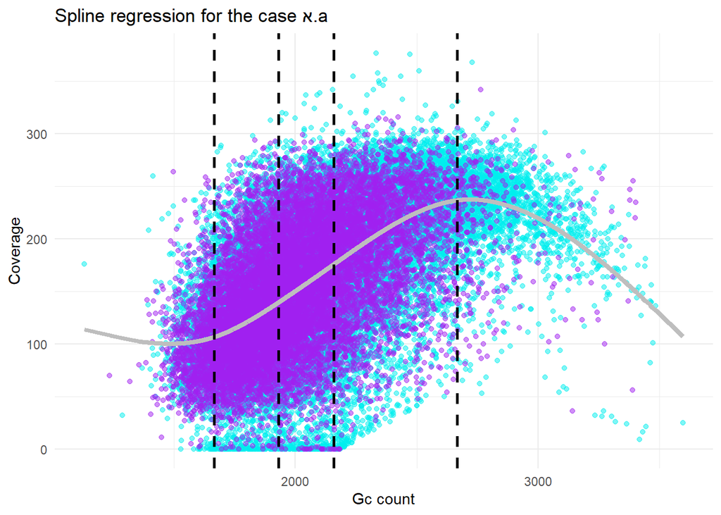

```r
n_parts <- 20
data$part <- cut(seq(1, nrow(data)), breaks = n_parts, labels = FALSE)

train_parts <- 1:14
test_parts <- 15:20

train_data_1 <- data[data$part %in% train_parts, ]
test_data_1 <- data[data$part %in% test_parts, ]

knots <- quantile(data$gc_content, probs = c(0.05, 0.35, 0.65, 0.95))
model_spline <- lm(coverage ~ ns(gc_content, knots = knots), data = train_data_1)

train_predictions_1 <- predict(model_spline, newdata = train_data_1)
test_predictions_1 <- predict(model_spline, newdata = test_data_1)


ggplot() +
  geom_point(data = train_data_1, aes(x = gc_content, y = coverage), color = 'cyan2', alpha = 0.5) +
  geom_line(data = train_data_1, aes(x = gc_content, y = train_predictions_1), color = 'grey', size = 1.5) +
  geom_point(data = test_data_1, aes(x = gc_content, y = coverage), color = 'purple', alpha = 0.5) +
  geom_line(data = test_data_1, aes(x = gc_content, y = test_predictions_1), color = 'grey', size = 1.5) +
  geom_vline(xintercept = knots, linetype = "dashed", color = "black", size = 1) +
  labs(title = "Spline regression for the case א.a",
       x = "Gc count",
       y = "Coverage") +
  theme_minimal()
```

### b :

The code aims to partition the data into training and testing sets, fit a spline regression model, and visualize the results.

We split the data by creating a partition where 70% is used for training and 30% for testing without considering the order. We fit then a spline regression model on the training data with coverage as the response and gc_content with specified knots as the predictor.

```r
set.seed(123)
train_indices2 <- createDataPartition(data$coverage, p = 0.7, list = FALSE)
train_data2 <- data[train_indices2, ]
test_data2 <- data[-train_indices2, ]


knots <- quantile(data$gc_content, probs = c(0.05, 0.35, 0.65, 0.95))
model_spline2 <- lm(coverage ~ ns(gc_content, knots = knots), data = train_data2)
print(model_spline2)
```

```
##
## Call:
## lm(formula = coverage ~ ns(gc_content, knots = knots), data = train_data2)
##
## Coefficients:
##                    (Intercept)  ns(gc_content, knots = knots)1
##                          92.29                           47.27
## ns(gc_content, knots = knots)2  ns(gc_content, knots = knots)3
##                          96.92                          182.94
## ns(gc_content, knots = knots)4  ns(gc_content, knots = knots)5
##                          88.69                           22.41
```

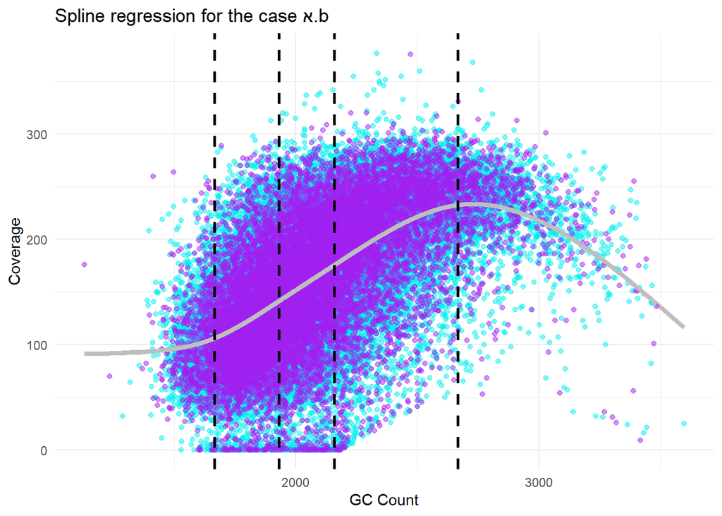

```r
train_predictions_2 <- predict(model_spline2, newdata = train_data2)
test_predictions_2 <- predict(model_spline2, newdata = test_data2)


ggplot() +
  geom_point(data = train_data2, aes(x = gc_content, y = coverage), color = 'cyan2', alpha = 0.5) +
  geom_line(data = train_data2, aes(x = gc_content, y = train_predictions_2), color = 'grey', size = 1.5) +
  geom_point(data = test_data2, aes(x = gc_content, y = coverage), color = 'purple', alpha = 0.5) +
  geom_line(data = test_data2, aes(x = gc_content, y = test_predictions_2), color = 'grey', size = 1.5) +
  geom_vline(xintercept = knots, linetype = "dashed", color = "black", size = 1) +
  labs(title = "Spline regression for the case א.b",
       x = "GC Count",
       y = "Coverage") +
  theme_minimal()
```

### c :

The code aims to partition the data into training and testing sets, fit a spline regression model, and visualize the results.

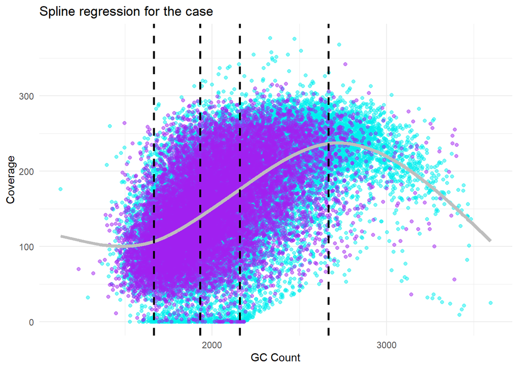

```r
n_total <- nrow(data)
n_train_3 <- round(0.7 * n_total)
n_test_3 <- n_total - n_train_3

train_data_3 <- data[1:n_train_3, ]
test_data_3 <- data[(n_train_3 + 1):n_total, ]

knots <- quantile(data$gc_content, probs = c(0.05, 0.35, 0.65, 0.95))
model_spline_3 <- lm(coverage ~ ns(gc_content, knots = knots), data = train_data_3)

train_predictions_3 <- predict(model_spline_3, newdata = train_data_3)
test_predictions_3 <- predict(model_spline_3, newdata = test_data_3)


ggplot() +
  geom_point(data = train_data_3, aes(x = gc_content, y = coverage), color = 'cyan2', alpha = 0.5) +
  geom_line(data = train_data_3, aes(x = gc_content, y = train_predictions_3), color = 'grey', size = 1.5) +
  geom_point(data = test_data_3, aes(x = gc_content, y = coverage), color = 'purple', alpha = 0.5) +
  geom_line(data = test_data_3, aes(x = gc_content, y = test_predictions_3), color = 'grey', size = 1.5) +
  geom_vline(xintercept = knots, linetype = "dashed", color = "black", size = 1) +
  labs(title = "Spline regression for the case",
       x = "GC Count",
       y = "Coverage") +
  theme_minimal()
```

## Part 3

Using a validation set allows the performance of the model to be evaluated objectively. If the model is evaluated only on the training data, it is possible that it is too adapted (overfitting) to the particularities of this data and does not generalize well to new data.

By separating the data into training and testing sets, one can check whether the model is able to generalize the trends learned from the training set to data it has never seen before. This helps identify if the model is too complex and fits the training data too closely.

The validation set allows different versions of the model or different models to be compared to each other on the same objective basis, i.e. data that they did not use for training.

We calculate the RMSE for train and test for each model to be able to determine which is the best model.

```r
rmse_train_a <- sqrt(mean((train_predictions_1 - train_data_1$coverage)^2))
rmse_test_a <- sqrt(mean((test_predictions_1 - test_data_1$coverage)^2))

cat("RMSE for the train set (case א.a): ", rmse_train_a, "\n")
```

```
## RMSE for the train set (case א.a):  50.16379
```

```r
cat("RMSE for the test set (case א.a): ", rmse_test_a, "\n")
```

```
## RMSE for the test set (case א.a):  51.20618
```

```r
rmse_train_b <- sqrt(mean((train_predictions_2 - train_data2$coverage)^2))
rmse_test_b <- sqrt(mean((test_predictions_2 - test_data2$coverage)^2))

cat("RMSE for the train set (case א.b): ", rmse_train_b, "\n")
```

```
## RMSE for the train set (case א.b):  50.35044
```

```r
cat("RMSE for the test set (case א.b): ", rmse_test_b, "\n")
```

```
## RMSE for the test set (case א.b):  50.6587
```

```r
rmse_train_c <- sqrt(mean((train_predictions_3 - train_data_3$coverage)^2))
rmse_test_c <- sqrt(mean((test_predictions_3 - test_data_3$coverage)^2))

cat("RMSE pour l'ensemble d'entraînement (cas א.c): ", rmse_train_c, "\n")
```

```
## RMSE pour l'ensemble d'entraînement (cas א.c):  50.16906
```

```r
cat("RMSE pour l'ensemble de test (cas א.c): ", rmse_test_c, "\n")
```

```
## RMSE pour l'ensemble de test (cas א.c):  51.19326
```

```r
diff_a <- abs(rmse_train_a - rmse_test_a)
diff_b <- abs(rmse_train_b - rmse_test_b)
diff_c <- abs(rmse_train_c - rmse_test_c)


results <- data.frame(
  Case = c("א.a", "א.b", "א.c"),
  RMSE_Train = c(rmse_train_a, rmse_train_b, rmse_train_c),
  RMSE_Test = c(rmse_test_a, rmse_test_b, rmse_test_c),
  Difference = c(diff_a, diff_b, diff_c)
)


print(results)
```

```
##   Case RMSE_Train RMSE_Test Difference
## 1  א.a   50.16379  51.20618  1.0423962
## 2  א.b   50.35044  50.65870  0.3082633
## 3  א.c   50.16906  51.19326  1.0241975
```

- Comparaison between our 3 models :

Case א.b has the smallest difference between training and testing RMSEs (0.3082633), suggesting that this model is the most stable and has the best generalization performance. The training and testing RMSEs for case א.b are also very close, indicating that this model does not overlearn the training data. Therefore, the best model based on stability and generalization performance is that of case א.b.

## Part 4

In this part, we draw 3 residuals graphs according to the explanatory variable, the predicted variable and the location of the chromosome (interval in question).

```r
residuals_train <- train_data2$coverage - train_predictions_2

residuals_test <- test_data2$coverage - test_predictions_2

head(residuals_train)
```

```
##          2          7          8         10         12         14
## -111.19079 -117.19956 -109.48329 -100.44511  -98.43183 -126.68261
```

```r
head(residuals_test)
```

```
##          9         11         13         15         24         32
## -110.05842  -99.07128 -116.38974  -97.59392 -110.19956 -179.14795
```

```r
train_predictions_2 <- predict(model_spline2, newdata = train_data2)
test_predictions_2 <- predict(model_spline2, newdata = test_data2)


head(train_predictions_2)
```

```
##        2        7        8       10       12       14
## 222.1908 118.1996 115.4833 121.4451 101.4318 150.6826
```

```r
head(test_predictions_2)
```

```
##        9       11       13       15       24       32
## 130.0584 112.0713 124.3897 106.5939 118.1996 180.1480
```

```r
train_indices <- as.numeric(rownames(train_data2))
test_indices <- as.numeric(rownames(test_data2))

train_df <- data.frame(Index = train_indices, y_pred = train_predictions_2)
test_df <- data.frame(Index = test_indices, y_pred = test_predictions_2)


combined_df <- rbind(train_df, test_df)


combined_df <- combined_df[order(combined_df$Index), ]
head(combined_df)
```

```
##    Index   y_pred
## 2      2 222.1908
## 7      7 118.1996
## 8      8 115.4833
## 9      9 130.0584
## 10    10 121.4451
## 11    11 112.0713
```

```r
comparison <- data.frame(x_values = data$gc_content, y_true = data$coverage, y_pred = combined_df$y_pred)


comparison$errors <- comparison$y_true - comparison$y_pred
print(head(comparison))
```

```
##   x_values y_true   y_pred     errors
## 1     2958    111 222.1908 -111.19079
## 2     1772      1 118.1996 -117.19956
## 3     1751      6 115.4833 -109.48329
## 4     1856     20 130.0584 -110.05842
## 5     1796     21 121.4451 -100.44511
## 6     1723     13 112.0713  -99.07128
```

We draw the graphs :

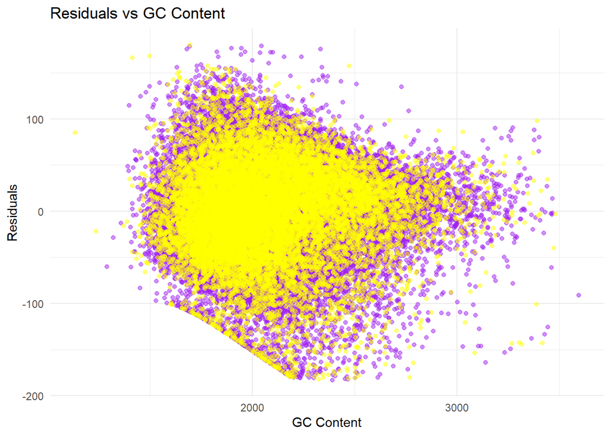

```r
residuals_train_df <- data.frame(gc_content = train_data2$gc_content, residuals = residuals_train)

residuals_test_df <- data.frame(gc_content = test_data2$gc_content, residuals = residuals_test)

ggplot() +
  geom_point(data = residuals_train_df, aes(x = gc_content, y = residuals), color = 'purple', alpha = 0.5) +
  geom_point(data = residuals_test_df, aes(x = gc_content, y = residuals), color = 'yellow', alpha = 0.5) +
  labs(title = "Residuals vs GC Content",
       x = "GC Content",
       y = "Residuals") +
  theme_minimal()
```

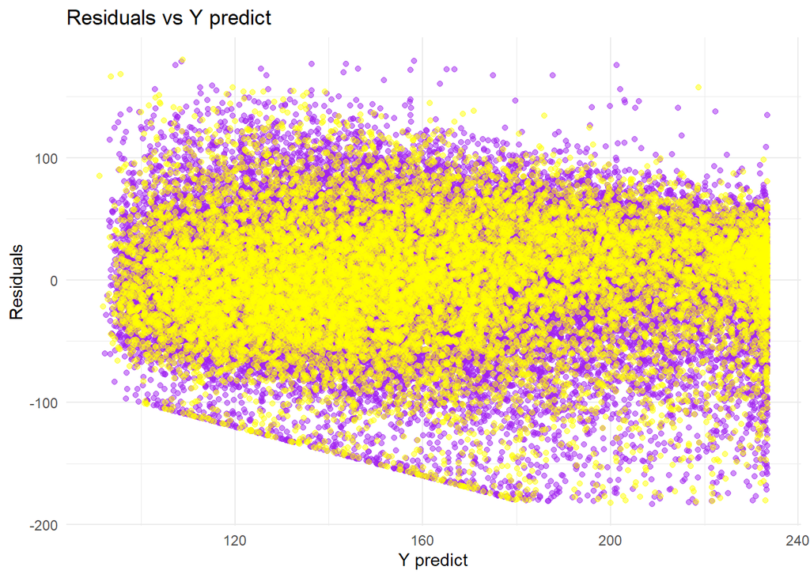

```r
ggplot() +
  geom_point(data = residuals_train_df, aes(x = train_predictions_2, y = residuals), color = 'purple', alpha = 0.5) +
  geom_point(data = residuals_test_df, aes(x = test_predictions_2, y = residuals), color = 'yellow', alpha = 0.5) +
  labs(title = "Residuals vs Y predict",
       x = "Y predict",
       y = "Residuals") +
  theme_minimal()
```

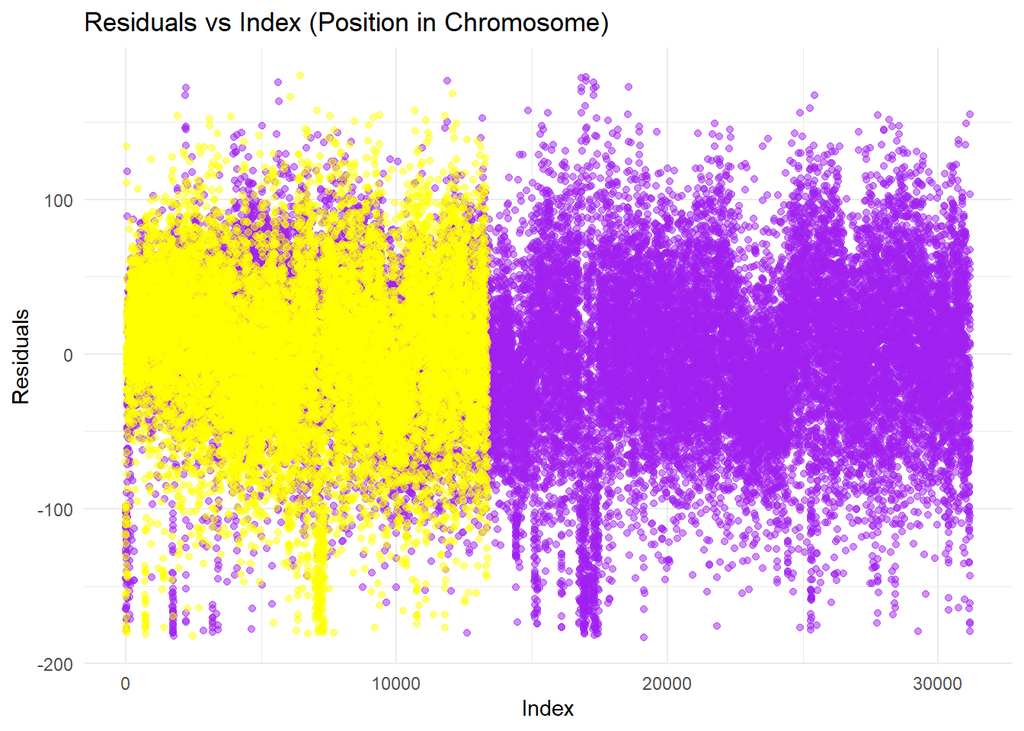

```r
residuals_train_df <- residuals_train_df %>%
  mutate(index = row_number())

residuals_test_df <- residuals_test_df %>%
  mutate(index = row_number())

# Tracer les résidus en fonction de l'index
ggplot() +
  geom_point(data = residuals_train_df, aes(x = index, y = residuals), color = 'purple', alpha = 0.5) +
  geom_point(data = residuals_test_df, aes(x = index, y = residuals), color = 'yellow', alpha = 0.5) +
  labs(title = "Residuals vs Index (Position in Chromosome)",
       x = "Index",
       y = "Residuals") +
  theme_minimal()
```

## b:

```r
cat("RMSE pour l'ensemble d'entraînement :", rmse_train_c, "\n")
```

```
## RMSE pour l'ensemble d'entraînement : 50.16906
```

```r
cat("RMSE pour l'ensemble de test :", rmse_test_c, "\n")
```

```
## RMSE pour l'ensemble de test : 51.19326
```

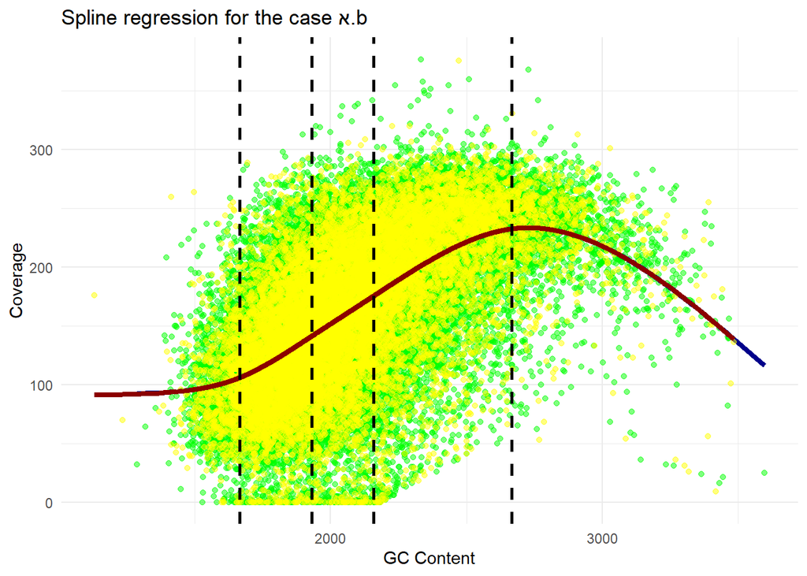

```r
ggplot() +
  geom_point(data = train_data2, aes(x = gc_content, y = coverage), color = 'green', alpha = 0.5) +
  geom_line(data = train_data2, aes(x = gc_content, y = train_predictions_2), color = 'darkblue', size = 1.5) +
  geom_point(data = test_data2, aes(x = gc_content, y = coverage), color = 'yellow', alpha = 0.5) +
  geom_line(data = test_data2, aes(x = gc_content, y = test_predictions_2), color = 'darkred', size = 1.5) +
  geom_vline(xintercept = knots, linetype = "dashed", color = "black", size = 1) +
  labs(title = "Spline regression for the case א.b",
       x = "GC Content",
       y = "Coverage") +
  theme_minimal()
```

The trend line (קו מגמה) seems to represent the general relationship well but could be improved to better capture local variations. The conditional mean line (קו התוחלת המותנית) could be refined with more complex models or regularization techniques.

So, while the trend line enhances the general understanding, it can be further improved by exploring more complex models and optimizing the spline regression parameters.

## Short summary

In this work, we wanted to know if the fact of distributing the data in 3 different ways would help us to choose the best possible approximation of our link between the number of reads and the number of GCs . We have tested 3 methods and have determined that a random distribution of 70% for training and 30% for testing bring us the greatest precision . We then drew the residus graphs according to several variables. Finally, we compared the line of the conditional esperance with the prediction line.